# Student housing data

Saša Krajnović

2023-06-12

```r
library(tidyverse)
library(ggplot2)
library(RColorBrewer)
```

## 0.1 Introduction

**For improved readability, majority of the code snippets have been initially concealed.** The option to display all code chunks is in the upper right corner, next to the title.

In this project student housing data in the academic year 2022/2023 was analyzed. The objective is to find suitable private accommodation among the collaborators of UP ŠSD that provide private accommodation for students.

Private accomodation is a solution for the majority of UP students. Out of 5745 students, only 439 can get a place to stay in the university dormitories.

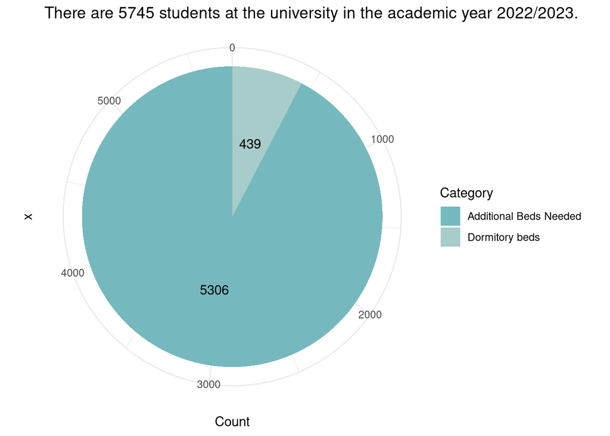

```r
data <- data.frame(
  Category = c("Dormitory beds", "Additional Beds Needed"),
  Count = c(94 + 160 + 130 + 55, 5745 - (94 + 160 + 130 + 55) )
)

data$Percentage <- data$Count / 5745 * 100


ggplot(data, aes(x = "", y = Count, fill = Category)) +
  geom_bar(width = 1, stat = "identity") +
  coord_polar("y", start = 0) +
  labs(title = "There are 5745 students at the university in the academic year 2022/2023.") +
  labs(fill = "Category") +
  scale_fill_manual(values = c("Dormitory beds" = "#A8CCC9", "Additional Beds Needed" = "#75B9BE")) +
  theme_minimal() +
  geom_text(aes(label = Count), position = position_stack(vjust = 0.5))
```

Sources: [UP Študentski domovi,](https://sd.upr.si/), [University UP in numbers](https://www.upr.si/en/about-university/up-in-numbers/)

### 0.1.1 Loading the data

The analyzed dataset is contained in stanovanja2.tsv. The data was received by the courtesy of [UP Študentski domovi](http://www.sd.upr.si/).

Due to difficulties with loading the original file, a .tsv file was created:

```r
data <- read.table("/home/sasha/r/stanovanja2.tsv", sep = "\t", header = TRUE, stringsAsFactors = FALSE)
```

```r
data<-data %>%
  select(-c(Ime, Priimek, Naslov, Posta, Kraj))
```

A function for editing the dataframe output is created to save time making the output more easily readable.

```r
nice_table<-function(df, pageLength = NULL) {

  #since pageLength option is not always needed,
  #options list has to be modified based on arguments provided
  options_list<-list(scrollX = TRUE)

  if (!is.null(pageLength)) {
    options_list$pageLength<-pageLength
  }

  DT::datatable(df, options = options_list)
}
```

```r
data %>%
  nice_table(., 5)
```

|  | Oddaja.v.na | Kontakt | Št..Ležišč | Elektronski.naslov |
| --- | --- | --- | --- | --- |
| 1 | POT POMORŠČAKOV 14A, 6320 PORTOROŽ | 068 176 612 | 3 | LJUDMILA.AVBELJ@GMAIL.COM |
| 2 | PARTIZANSKA 12F, KOPER | 041 346 990 | 5 | INFO@KONDITOR.SI |
| 3 | KIDRIČEVA 12, 6000 KOPER | 031 646 030 | 6 | INFO@GAST.SI |
| 4 | OSVOBODILNE FRONTE 2, 6000 KOPER | 031 646 030 | 4 | INFO@GAST.SI |
| 5 | POT V GAJ 5, 6000 KOPER | 031 367 482 | 3 | ZLATA.BARUCA@GMAIL.COM |
| 6 | SOŠKA 3, 6000 KOPER | 040 687 380 | 2 | IGORBENEDETTI1@GMAIL.COM |
| 7 | CVETNA POT 11, 6320 PORTOROŽ | 031 653 675 | 5 | LJUBO.BERTOK@GMAIL.COM |
| 8 | OBALA 126, 6320 LUCIJA | 040 234 625 | 5 | IZIDOR.BOGATAJ.CI@GMAIL.COM |
| 9 | VOJKOVO NABREŽJE 31A, 6000 KOPER | 041 528 910 | 2 | MADAM.BOHIINC@GMAIL.COM |
| 10 | MARUŠIČEVA UL. 23, 6000 KOPER | 031 855 277, 031 448 550 | 6 | MIRAN.BORDON@YAHOO.COM |

[output cut: 145 more lines]

### 0.1.2 What the original data looks like

Let us see what the data looks like. `ncol(data)` outputs that there are 4 columns, namely:

```r
colnames(data)
```

```
## [1] "Oddaja.v.na"        "Kontakt"            "Št..Ležišč"
## [4] "Elektronski.naslov"
```

and the classes of respective columns are:

```r
sapply(data, class) %>%
  data.frame(column = names(.), class = ., row.names = NULL) %>%
  nice_table()
```

|  | column | class |
| --- | --- | --- |
| 1 | Oddaja.v.na | character |
| 2 | Kontakt | character |
| 3 | Št..Ležišč | character |
| 4 | Elektronski.naslov | character |

#### 0.1.2.1 Which column contains which data?

| column name | data | class |
| --- | --- | --- |
| Oddaja.v.na | address of the flat | character |
| Kontakt | contact (phone) | character |
| Št..Ležišč | number of beds | character |
| Elektronski.naslov | e-mail | character |

Renaming columns:

```r
#substituting dot with underscore
colnames(data) <- gsub("\\.", "_", colnames(data))
#changing all letters to lowercase
colnames(data)<-tolower(colnames(data))
colnames(data)
```

```
## [1] "oddaja_v_na"        "kontakt"            "št__ležišč"
## [4] "elektronski_naslov"
```

## 0.2 Modifying the data

To start with, let’s glimpse into data to see data values per columns:

```r
glimpse(data)
```

```
## Rows: 155
## Columns: 4
## $ oddaja_v_na        <chr> "POT POMORŠČAKOV 14A, 6320 PORTOROŽ", "PARTIZANSKA …
## $ kontakt            <chr> "068 176 612", "041 346 990", "031 646 030", "031 6…
## $ št__ležišč         <chr> "3", "5", "6", "4", "3", "2", "5", "5", "2", "6", "…
## $ elektronski_naslov <chr> "LJUDMILA.AVBELJ@GMAIL.COM", "INFO@KONDITOR.SI", "I…
```

Some problems are immediately visible:

- all characters are uppercase (this makes email adresses unusable)
- number of beds is character

### 0.2.1 Email addresses

Converting email-address to lowercase:

```r
data$elektronski_naslov<-tolower(data$elektronski_naslov)
data %>%
  nice_table(., 5)
```

|  | oddaja_v_na | kontakt | št__ležišč | elektronski_naslov |
| --- | --- | --- | --- | --- |
| 1 | POT POMORŠČAKOV 14A, 6320 PORTOROŽ | 068 176 612 | 3 | ljudmila.avbelj@gmail.com |
| 2 | PARTIZANSKA 12F, KOPER | 041 346 990 | 5 | info@konditor.si |
| 3 | KIDRIČEVA 12, 6000 KOPER | 031 646 030 | 6 | info@gast.si |
| 4 | OSVOBODILNE FRONTE 2, 6000 KOPER | 031 646 030 | 4 | info@gast.si |
| 5 | POT V GAJ 5, 6000 KOPER | 031 367 482 | 3 | zlata.baruca@gmail.com |
| 6 | SOŠKA 3, 6000 KOPER | 040 687 380 | 2 | igorbenedetti1@gmail.com |
| 7 | CVETNA POT 11, 6320 PORTOROŽ | 031 653 675 | 5 | ljubo.bertok@gmail.com |
| 8 | OBALA 126, 6320 LUCIJA | 040 234 625 | 5 | izidor.bogataj.ci@gmail.com |
| 9 | VOJKOVO NABREŽJE 31A, 6000 KOPER | 041 528 910 | 2 | madam.bohiinc@gmail.com |
| 10 | MARUŠIČEVA UL. 23, 6000 KOPER | 031 855 277, 031 448 550 | 6 | miran.bordon@yahoo.com |

[output cut: 145 more lines]

Our following problem is that during the conversion process to uppercase in the original data and this conversion to lowercase resulted in **incorrect address if it originally contained both uppercase and lowercase letters** (which is not that usual, but it is a possibility). This means we can’t really know if the data is usable or not.

However, gmail mail service offers a feature that can help us a bit. Since it shows existing accounts upon typing in the email adress, we can confirm if the adress exists before even writing the email.

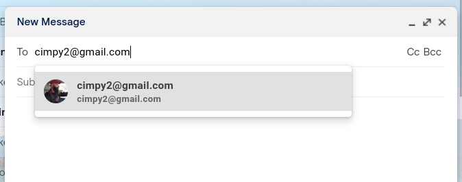

Gmail confirms the email message.

Let’s extract the flats that have a gmail adress, which ensures that the email address can be confirmed easily:

```r
data$email_provider<-gsub("^.*@([^.]+)\\..*$", "\\1", data$elektronski_naslov)

data %>%
  select(elektronski_naslov, email_provider) %>%
  nice_table(., 5)
```

|  | elektronski_naslov | email_provider |
| --- | --- | --- |
| 1 | ljudmila.avbelj@gmail.com | gmail |
| 2 | info@konditor.si | konditor |
| 3 | info@gast.si | gast |
| 4 | info@gast.si | gast |
| 5 | zlata.baruca@gmail.com | gmail |
| 6 | igorbenedetti1@gmail.com | gmail |
| 7 | ljubo.bertok@gmail.com | gmail |
| 8 | izidor.bogataj.ci@gmail.com | gmail |
| 9 | madam.bohiinc@gmail.com | gmail |
| 10 | miran.bordon@yahoo.com | yahoo |

[output cut: 145 more lines]

So here are the values for email providers:

```r
emails<-table(data$email_provider) %>%
  data.frame(provider = names(.), frequency = as.numeric(.)) %>%
  select(provider, frequency)
emails %>%
  nice_table()
```

|  | provider | frequency |
| --- | --- | --- |
| 1 |  | 30 |
| 2 | / | 2 |
| 3 | a1 | 1 |
| 4 | apartmaji@slavnik-si | 1 |
| 5 | gast | 2 |
| 6 | gmail | 93 |
| 7 | goriske | 1 |
| 8 | guest | 2 |
| 9 | hotmail | 1 |
| 10 | hydrovod | 1 |

[output cut: 9 more lines]

Let’s visualize this, excluding the empty values (i.e. ““,”/“) and the apparent mistake in case of”apartmaji@slavnik-si” value:

```r
emails_clean<-emails %>%
  dplyr::filter(!(provider %in% c("", "/", "apartmaji@slavnik-si")))
```

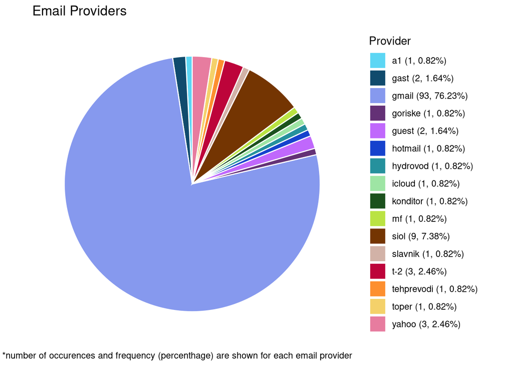

```r
#vector that contains color palette
my_colors<-c("#5cd6f4", "#104b6d", "#8699ee", "#643176", "#c068fc", "#1642cd", "#25919d", "#9ee5a4", "#1b511d", "#bae342", "#743502", "#d2b2a7", "#bd043a", "#fd8f2f", "#f4d16a", "#e77c9f")
#generated with http://vrl.cs.brown.edu/color

#declaring vector with percentage values
percentages<-round(emails_clean$frequency/sum(emails_clean$frequency) * 100, 2)

#declaring vector with label values, to be added in the plot manually
legend_labels<-paste(emails_clean$provider, " ", "(", emails_clean$frequency,", ", percentages, "%)", sep = "")

#plotting
ggplot(emails_clean, aes(x = "", y = frequency, fill = provider)) +
  geom_bar(stat = "identity", width = 1, color = "white") +
  coord_polar("y", start = 0) +
  labs(fill = "", x = NULL, y = NULL, title = "Email Providers", caption = "*number of occurences and frequency (percenthage) are shown for each email provider") +
  theme_minimal() +
  theme(axis.text = element_blank(), axis.title = element_blank(), panel.grid = element_blank()) +
  scale_fill_manual(
    values = my_colors,
    labels = legend_labels,
    guide = guide_legend(title = "Provider")
  )
```

We can immediately see that majority of the email adresses are gmail, which makes majority of the data usable. By adding **email_provider** column, we can filter such data later on more easily.

### 0.2.2 Extracting the town

Probably the most important condition for choosing the flat is the town it is located in. This information is located at the end of oddaja_v_na column, so let’s extract the last word from it in order to get the town :

```r
#ensuring there are no extra spaces
data$oddaja_v_na<-str_trim(data$oddaja_v_na)

data$town <- sapply(strsplit(data$oddaja_v_na, "\\s+"), function(x) ifelse(length(x) > 1, tail(x, 1), NA))
#since "NOVA GORICA" is the only town with 2 words, we have to change all GORICA entries to NOVA GORICA
data<-data %>%
   mutate(town = str_replace(town, "GORICA", "NOVA GORICA")) %>%
  select(town, everything())

data %>% nice_table(.,5)
```

|  | town | oddaja_v_na | kontakt | št__ležišč | elektronski_naslov | email_provider |
| --- | --- | --- | --- | --- | --- | --- |
| 1 | PORTOROŽ | POT POMORŠČAKOV 14A, 6320 PORTOROŽ | 068 176 612 | 3 | ljudmila.avbelj@gmail.com | gmail |
| 2 | KOPER | PARTIZANSKA 12F, KOPER | 041 346 990 | 5 | info@konditor.si | konditor |
| 3 | KOPER | KIDRIČEVA 12, 6000 KOPER | 031 646 030 | 6 | info@gast.si | gast |
| 4 | KOPER | OSVOBODILNE FRONTE 2, 6000 KOPER | 031 646 030 | 4 | info@gast.si | gast |
| 5 | KOPER | POT V GAJ 5, 6000 KOPER | 031 367 482 | 3 | zlata.baruca@gmail.com | gmail |
| 6 | KOPER | SOŠKA 3, 6000 KOPER | 040 687 380 | 2 | igorbenedetti1@gmail.com | gmail |
| 7 | PORTOROŽ | CVETNA POT 11, 6320 PORTOROŽ | 031 653 675 | 5 | ljubo.bertok@gmail.com | gmail |
| 8 | LUCIJA | OBALA 126, 6320 LUCIJA | 040 234 625 | 5 | izidor.bogataj.ci@gmail.com | gmail |
| 9 | KOPER | VOJKOVO NABREŽJE 31A, 6000 KOPER | 041 528 910 | 2 | madam.bohiinc@gmail.com | gmail |
| 10 | KOPER | MARUŠIČEVA UL. 23, 6000 KOPER | 031 855 277, 031 448 550 | 6 | miran.bordon@yahoo.com | yahoo |

[output cut: 145 more lines]

#### 0.2.2.1 Which towns are present in the data?

```r
data$town %>% unique
```

```
##  [1] "PORTOROŽ"    "KOPER"       "LUCIJA"      "NOVA GORICA" "POBEGI"
##  [6] "DUTOVLJE"    "PIRAN"       "IZOLA"       "ANKARAN"     "1,KOPER"
## [11] NA            "SUBVENCIJE"  "SEČOVLJE"    "SEŽANA"
```

Now let’s fix the mistakes in the cities. Value “1,KOPER” is obviously just “KOPER”, and “SUBVENCIJE” should be NA.

This is what the result looks like:

```r
data$town<-gsub("1,KOPER", "KOPER", data$town)
data$town<-gsub("SUBVENCIJE", NA, data$town)
data$town %>% unique
```

```
##  [1] "PORTOROŽ"    "KOPER"       "LUCIJA"      "NOVA GORICA" "POBEGI"
##  [6] "DUTOVLJE"    "PIRAN"       "IZOLA"       "ANKARAN"     NA
## [11] "SEČOVLJE"    "SEŽANA"
```

#### 0.2.2.2 Towns int the dataset visualisation

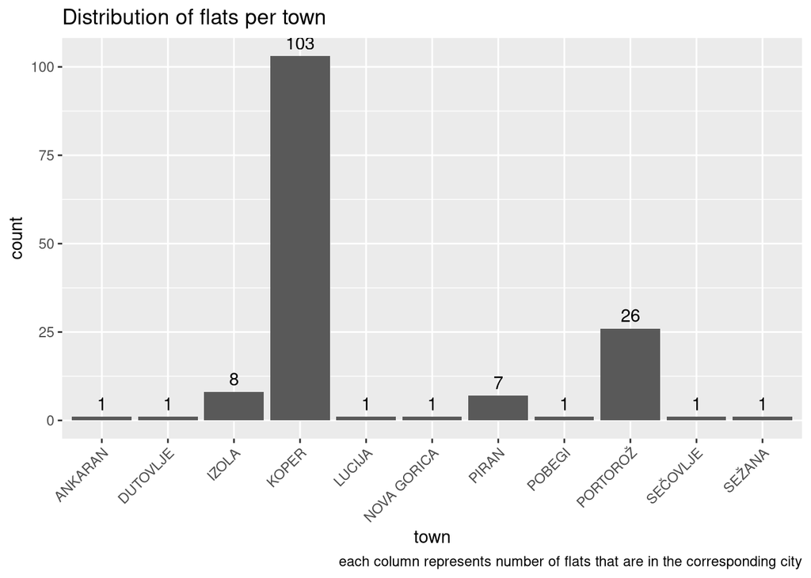

```r
data %>%
  dplyr::filter(!is.na(town)) %>%
  ggplot(aes(x = town)) +
  geom_histogram(stat = "count") +
  theme(axis.text.x = element_text(angle = 45, hjust = 1)) +
  geom_text(
    stat = "count",
    aes(label = ..count..),
    vjust = -0.5,
    color = "black"
  ) +
  labs(title = "Distribution of flats per town", caption = "each column represents number of flats that are in the corresponding city")
```

It is clear that the top 3 towns with the **highest number of flats** are:

```r
data %>%
  dplyr::filter(!is.na(town)) %>%
  count(town) %>%
  rename(no_of_flats = n) %>%
  slice_max(n = 3, order_by = no_of_flats) %>%
  nice_table()
```

|  | town | no_of_flats |
| --- | --- | --- |
| 1 | KOPER | 103 |
| 2 | PORTOROŽ | 26 |
| 3 | IZOLA | 8 |

### 0.2.3 Extracting the postal codes of the towns

Since I don’t know what postal codes correspond to which town, I will extract the postal code and match them to the corresponding towns (for those entries that do have a postal code).

```r
#extracting postal code
data$postal_code<-as.numeric(str_extract(data$oddaja_v_na, "\\b\\d{4}\\b"))
#matching towns to codes (for those that have a code)
data %>%
  select(postal_code, town) %>%
  distinct() %>%
  na.omit()
```

```
##    postal_code        town
## 1         6320    PORTOROŽ
## 3         6000       KOPER
## 4         6320      LUCIJA
## 5         5000 NOVA GORICA
## 6         6276      POBEGI
## 8         6330       PIRAN
## 9         6310       IZOLA
## 11        6280     ANKARAN
## 12        3620    PORTOROŽ
## 15        6333    SEČOVLJE
```

### 0.2.4 Numbers of beds in flats

Firstly, let’s extract flats in towns where there is only one flat for rent per town to see how many beds there are in those flats.

```r
flatsInTowns<-data %>%
  count(town, št__ležišč)


townsAppearance<-flatsInTowns %>%
  group_by(town) %>%
  summarize(total_appearances = sum(n))


filteredFlats<-flatsInTowns  %>%
  left_join(townsAppearance, by = "town")

oneFlatPerTown<-filteredFlats %>%
  dplyr::filter(total_appearances==1)

data %>%
  dplyr::filter(town %in% oneFlatPerTown$town) %>%
  select(town, št__ležišč, everything()) %>%
  nice_table()
```

|  | town | št__ležišč | oddaja_v_na | kontakt | elektronski_naslov | email_provider | postal_code |
| --- | --- | --- | --- | --- | --- | --- | --- |
| 1 | LUCIJA | 5 | OBALA 126, 6320 LUCIJA | 040 234 625 | izidor.bogataj.ci@gmail.com | gmail | 6320 |
| 2 | NOVA GORICA | 4 | CANKARJEVA 52, 5000 NOVA GORICA | 031 381 710 | vanja.bozic1@gmail.com | gmail | 5000 |
| 3 | POBEGI | 6 | CESTA I. ISTRSKE BRIGADE 20, 6276 POBEGI | 031 282 112 | irena.breznik4@gmail.com | gmail | 6276 |
| 4 | DUTOVLJE | 6 | DUTOVLJE 2/A, DUTOVLJE | 040 439 368 | feroks.mail@gmail.com | gmail |  |
| 5 | ANKARAN | 4 | VLAHOVIČEVA 13, 6280 ANKARAN | 041 425 777 |  |  | 6280 |
| 6 | SEČOVLJE | 2 | SEČOVLJE ŠT. 67, 6333 SEČOVLJE | 040 886 459 | nvolaric@gmail.com | gmail | 6333 |
| 7 | SEŽANA | 6 | CESTA NA LENIVEC 7, SEŽANA | 031 804 610 | bbroomsnataly@gmail.com | gmail |  |

This table can also serve as a table for finding accomodation in the following towns:

```r
data %>%
  dplyr::filter(town %in% oneFlatPerTown$town) %>%
  distinct(town)
```

```
##          town
## 1      LUCIJA
## 2 NOVA GORICA
## 3      POBEGI
## 4    DUTOVLJE
## 5     ANKARAN
## 6    SEČOVLJE
## 7      SEŽANA
```

Now let’s visualize distribution of number of beds per flat in towns that have more than 1 flat for rent.

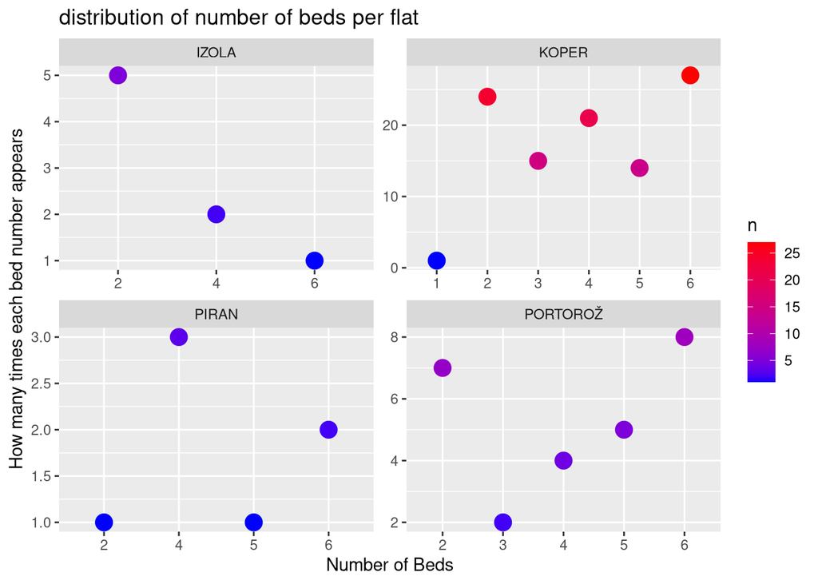

```r
filteredFlats%>%
  dplyr::filter(total_appearances != 1) %>%
  dplyr::filter(!(št__ležišč %in% c("ZASEDENO", NA, ""))) %>%
  na.omit %>%
  ggplot(., aes(x = št__ležišč, y=n, size = 3, color = n)) +
  geom_point() +
  facet_wrap(~ town, scales = "free") +
  labs(x = "Number of Beds", y = "How many times each bed number appears", title = "distribution of number of beds per flat ") +
  scale_color_gradient(low = "blue", high = "red") +
  guides(size = "none")
```